# Cache

#computer_architecture #computer_science

Caches are crucial part of modern CPUs. Modern processors are much faster than modern Memory. By adding small inner memories that hold copies of data in big memories, it is achievable to effectively have extremely large memory with extremely fast access.

**Hit Rate** - fraction of accesses that hit in the cache **Miss Rate** - $1 - \text{Hit Rate}$ **Miss Penalty** - time to replace block in cache **Hit Time** - time to access cache memory

**Average Memory Access Time AMAT** - $\text{Hit time} + \text{Miss Rate} \cdot \text{Miss Penalty}$

Even very small cache provides enormous benefits.

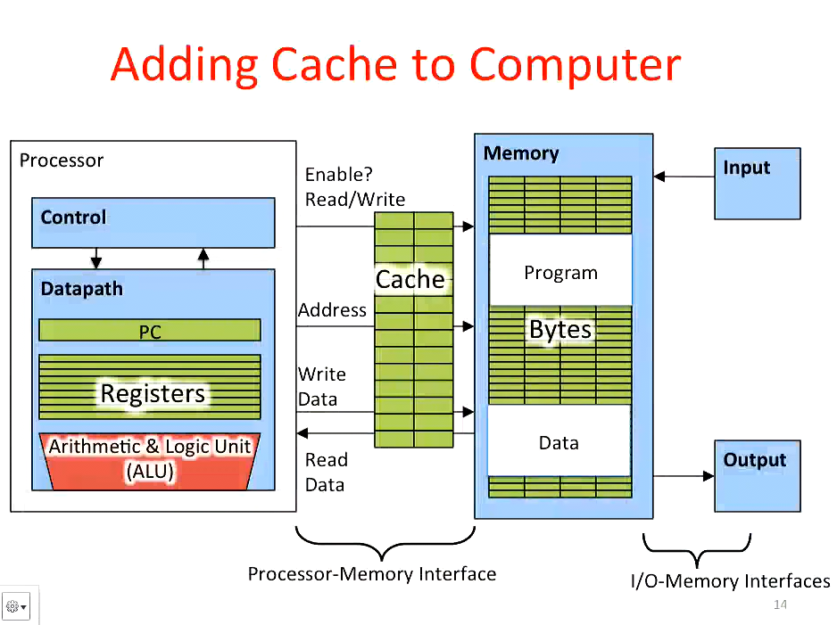

Cache_Schematic.png

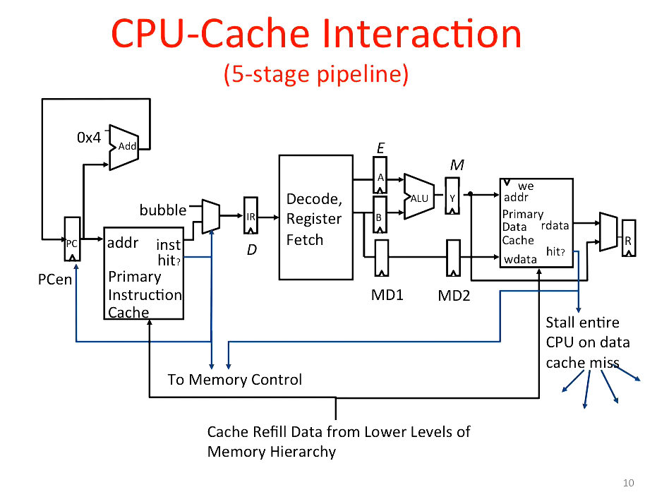

Cache_CPU.png

## Locality

What allows caches to be effective is that similar data tends to be accessed. **Temporal Locality** - data gets accessed repeatedly (variables, loops) **Spatial Locality** - data nearby is likely to get accessed again (arrays, stack, functions)

## Structure

Cache entry is structured as `valid | tag | data`. Where tag is address from where the entry was taken. There might also be `valid | dirty | tag | data` in the case when data is modified in cache and later written back into memory.

To reduce the need for comparators, cache can be partitioned into sets. Each set can hold data from certain section of memory. This leads to two extremes - fully associative cache where each memory location can go anywhere (aka one set) and direct mapped where each memory location has only one valid spot (aka set count equals cache entry count).

Cache generally fetches data in block size - which is several words.

Cache controller uses: - block offset byte address within block - set index selects which set $\text{size} = \log_2 \left( \text{set count} \right)$ - tag remaining portion of processor address $\text{size} = \text{address size} - \text{index size} - \log_2 \left( \text{bytes per block} \right)$

It is possible to start accessing cache and memory in parallel, but usually it is not a reasonable choice because cache is supposed to almost always hit and because memory might not be able to keep up with that many requests.

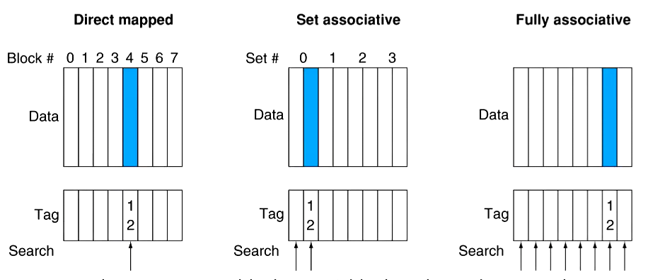

Cache_Structures.png

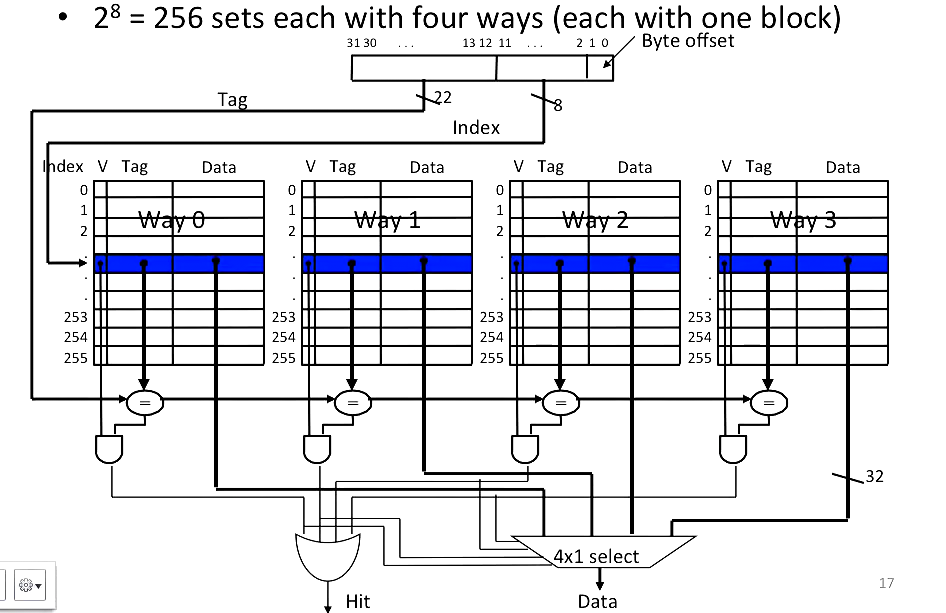

Cache_Construction.png

## Stores

One problem is stores, when data is updated in cache it stops being coherent with original memory. **Write-Through** is when BOTH cache and memory are updated. Generally requires write buffer to be fast enough. On miss only replacement is done. **Write-Back** is when dirty bit is used and memory is only updated during eviction. On miss, write has to happen first.

When block is not allocated again two possibilities occur. **Write-Allocate** is when on write data is fetched into cache. **No Write-Allocate** is when data is written to memory and not put into cache.

In general, any combination of above is possible but typically WT + NWA and WB + WA.

## Replacement Policy

- Random Surprisingly good Avoids pathological cases
- Least Recently Used Nice for 2 way set associative, gets complex quickly
- Pseudo LRU Binary tree LRU, usable for 4 or 8 way set associative
- FIFO Used in highly associative
- NLRU FIFO with exception for the least recently used

## Cache Misses

- Compulsory First time accessing memory can not fully avoid, but not very important somewhat solvable by increasing block size

  measured by setting size to infinity and fully associative and then counting number of misses
- Capacity Cache cannot hold all blocks

  solvable by increasing cache size but it may lead to larger access time

  measured by setting cache to fully associative and subtracting compulsory misses
- Conflict Multiple locations mapped to the same location

  solvable by increasing cache size and associativity but it may lead to larger access time

  Measured by measuring cache misses and subtracting Compulsory and Capacity misses
- Coherence Caused by traffic with other cores

## Performance

Often, there are certain steps in cache because suddenly working set is fully in cache and it provides benefits again.

Ways to increase performance are: - Reducing time to hit smaller cache - Reducing miss rate larger cache - Reducing miss penalty multiple level cache

Increasing block size leads to: - Hit time unchanged or small reduction - Miss rate first reduction then increase - Miss Penalty Increase but typically amortized Increasing Associativity leads to - Hit time Increase, huge jump initially - Miss rate Decrease, most gain at the beginning - Miss Penalty Unchanged Increasing entry count leads to - Hit time Increase - Miss Rate Decrease - Miss Penalty Unchanged

## Parameters

- Block size
- Associativity
- Capacity
- Entry count

## Multilevel

There is a lot of locality that might be impossible to exploit at lower levels, several cache levels are used.

**Local Miss Rate** is how much that particular cache misses when accessing outwards. **Global Miss Rate** is how much accesses miss in all cache levels.

## Lectures

- CS61C - UCB

#lecture_cs61c_ucb

%%

## TODO

- why in the world does increase in block size leads to more misses
- better organization